# CytoCrunch: Flow Cytometry Analysis Pipeline

Clustering, Dimensionality Reduction & Visualization Demo

Joshua Luthy

2026-11-12

# Overview

**CytoCrunch** is an R package that bridges FlowJo’s plugin ecosystem and Bioconductor workflows for flow cytometry data analysis. It provides a unified S4 object system for managing, transforming, clustering, and visualizing high-parameter cytometry data at scale.

This notebook demonstrates the core analytical pipeline:

1. **Data loading** — importing FlowJo-exported CSV data into CytoCrunch objects
2. **Clustering** — automated cell population discovery with FlowSOM, or with the dependency-light `SOM` method
3. **Dimensionality reduction** — t-SNE and UMAP embeddings for visualization
4. **Visualization** — publication-ready plots including embeddings, heatmaps, and merged multi-sample views

**Note** — All data shown uses the built-in demo dataset: 3,000 cells each from four tissue types (Blood, Liver, Lymph Node, Spleen), exported from FlowJo as extended node CSVs.

# Setup

## Load CytoCrunch and Dependencies

```r
devtools::load_all(here::here())
library(ggplot2)
library(gridExtra)
```

# Data Loading

## The CytoCrunch S4 Object

CytoCrunch uses a custom **S4 object system** to encapsulate all analysis state — raw data, clustering results, embeddings, and plots — in a single, self-contained object. This design ensures reproducibility and enables seamless chaining of analytical steps.

Each `CytoCrunch` object is initialized from a FlowJo-exported CSV file:

```r
# ── Load all four demo datasets in one call ───────────────────────────────────
demo      <- loadDemoData()
blood     <- demo$blood
lymphNode <- demo$lymphNode
liver     <- demo$liver
spleen    <- demo$spleen
```

## Inspect the Object

```r
# Object structure — S4 slots
slotNames(blood)
```

```
#> [1] "sampleName"          "inputCSV"            "parameterNames"
#> [4] "flowFrameFJ"         "clusteringList"      "dimReductionList"
#> [7] "batchCorrectionList" "plotList"
```

```r
# Sample name
blood@sampleName
```

```
#> [1] "Blood3k"
```

```r
# Preview the expression matrix dimensions
dim(blood@inputCSV$X)
```

```
#> [1] 3000   18
```

```r
# Preview the first few rows and marker columns
head(blood@inputCSV$X[, 1:8])
```

```
#>      Comp-FITC-A :: CCR7 Comp-PerCP-Cy5-5-A :: CD16 Comp-APC-A :: CD95
#> [1,]                 447                        347                286
#> [2,]                 310                        321                245
#> [3,]                 297                        358                283
#> [4,]                 314                        392                263
#> [5,]                 559                        437                307
#> [6,]                 304                        372                809
#>      Comp-Alexa Fluor 700-A :: CD8a Comp-APC-Cy7-A :: CD45
#> [1,]                            410                    669
#> [2,]                            625                    715
#> [3,]                            290                    659
#> [4,]                            334                    692
#> [5,]                            735                    655
#> [6,]                            349                    675
#>      Comp-BV421-A :: CD45RO Comp-BV510-A :: CD3 Comp-BV605-A :: CD123
#> [1,]                    443                 677                   366
#> [2,]                    461                 678                   219
#> [3,]                    312                 210                   383
#> [4,]                    281                 250                   386
#> [5,]                    303                 540                   412
#> [6,]                    609                 718                   394
```

## Available Markers

```r
# Derive display labels: stain name where available, else parameter name
stainNames   <- blood@parameterNames$fjStainNames
parNames     <- blood@parameterNames$fjParNames
markerLabels <- ifelse(is.na(stainNames), parNames, stainNames)
markerLabels
```

```
#>            Comp-FITC-A :: CCR7     Comp-PerCP-Cy5-5-A :: CD16
#>                         "CCR7"                         "CD16"
#>             Comp-APC-A :: CD95 Comp-Alexa Fluor 700-A :: CD8a
#>                         "CD95"                         "CD8a"
#>         Comp-APC-Cy7-A :: CD45         Comp-BV421-A :: CD45RO
#>                         "CD45"                       "CD45RO"
#>            Comp-BV510-A :: CD3          Comp-BV605-A :: CD123
#>                          "CD3"                        "CD123"
#>           Comp-BV650-A :: CD71           Comp-BV711-A :: CD14
#>                         "CD71"                         "CD14"
#>           Comp-BV786-A :: CD19              Comp-PE-A :: CD25
#>                         "CD19"                         "CD25"
#>       Comp-PE-CF594-A :: NKG2D          Comp-PE-Cy5-A :: CD56
#>                        "NKG2D"                         "CD56"
#>        Comp-PE-Cy7-A :: HLA-DR                  Comp-BUV395-A
#>                       "HLA-DR"                "Comp-BUV395-A"
#>    Comp-Indo-1 (Blue)-A :: CD4         Comp-BUV737-A :: CD127
#>                          "CD4"                        "CD127"
```

# Clustering

## FlowSOM Clustering

CytoCrunch uses **FlowSOM** for automated, unsupervised cell population discovery. The `performClustering()` function wraps the FlowSOM algorithm and stores results directly in the S4 object, tagged with a unique `runID` for tracking multiple analyses.

### Blood — 12 Clusters

```r
blood <- performClustering(blood,
                           runID  = "BLOOD_C12",
                           method = "FlowSOM",
                           k      = 12)
```

### Lymph Node — 15 Clusters

```r
lymphNode <- performClustering(lymphNode,
                               runID  = "LN_C15",
                               method = "FlowSOM",
                               k      = 15)
```

### Liver — 12 Clusters

```r
liver <- performClustering(liver,
                           runID  = "LIVER_C12",
                           method = "FlowSOM",
                           k      = 12)
```

### Spleen — 12 Clusters

```r
spleen <- performClustering(spleen,
                            runID  = "SPLEEN_C12",
                            method = "FlowSOM",
                            k      = 12)
```

## SOM Clustering (No Bioconductor Required)

FlowSOM is distributed through Bioconductor, which can be inconvenient to install. CytoCrunch therefore also offers `method = "SOM"`. It trains a self-organising map with **EmbedSOM** (available from CRAN), clusters the map’s node codebook vectors with Ward hierarchical clustering into `k` groups, and gives each cell the label of its node. It needs only EmbedSOM, and accepts the same `k` and `runID` arguments as FlowSOM. Optional `xdim`, `ydim`, `rlen` and `seed` arguments control the map size, training length and reproducibility.

Here we cluster the same Blood data again with `SOM`, under a separate `runID`, so the two methods can be compared side by side later on:

```r
blood <- performClustering(blood,
                           runID  = "BLOOD_SOM12",
                           method = "SOM",
                           k      = 12,
                           seed   = 1)
```

**FlowSOM vs SOM** — The two methods build the same kind of self-organising map but differ in the metaclustering step (FlowSOM uses consensus clustering, `SOM` uses Ward hierarchical clustering), so cluster labels and boundaries will not be identical even for the same `k`. Use FlowSOM when you need results comparable to FlowJo’s own FlowSOM plugin.

**Run IDs** — Each clustering and embedding call is tagged with a `runID` string. This lets you store multiple analyses (different `k` values, methods, parameters) on the same object and reference them independently downstream.

# Dimensionality Reduction

## Embedding Methods

CytoCrunch supports both **t-SNE** and **UMAP** for 2D embedding of high-dimensional cytometry data. Like clustering, embeddings are stored on the object and referenced by `runID`.

### Blood — t-SNE

```r
blood <- performEmbedding(blood,
                          runID    = "BLOOD_C12",
                          method   = "tsne",
                          fjSeed   = 123,
                          fjXdim   = 10,
                          fjYdim   = 10,
                          fjRLEN   = 15,
                          fjK      = 10,
                          fjAdjust = 0,
                          fjSmooth = 0,
                          fjMapSize = 2000)
```

### Lymph Node — UMAP

```r
lymphNode <- performEmbedding(lymphNode,
                              runID      = "LN_C15",
                              method     = "umap",
                              fjSeed     = 42,
                              fjXdim     = 10,
                              fjYdim     = 10,
                              fjRLEN     = 22,
                              fjK        = 12,
                              fjAdjust   = 0,
                              fjSmooth   = 1,
                              fjUmap.Dist = 0.4,
                              fjMapSize   = 2000)
```

### Liver — UMAP

```r
liver <- performEmbedding(liver,
                          runID      = "LIVER_C12",
                          method     = "umap",
                          fjSeed     = 77,
                          fjXdim     = 10,
                          fjYdim     = 10,
                          fjRLEN     = 20,
                          fjK        = 10,
                          fjAdjust   = 0,
                          fjSmooth   = 1,
                          fjUmap.Dist = 0.3,
                          fjMapSize   = 2000)
```

### Spleen — UMAP

```r
spleen <- performEmbedding(spleen,
                           runID      = "SPLEEN_C12",
                           method     = "umap",
                           fjSeed     = 99,
                           fjXdim     = 10,
                           fjYdim     = 10,
                           fjRLEN     = 18,
                           fjK        = 11,
                           fjAdjust   = 0,
                           fjSmooth   = 1,
                           fjUmap.Dist = 0.35,
                           fjMapSize   = 2000)
```

# Visualization

## Embedding Plots with Cluster Overlay

The `plotEmbeddingWithClusters()` function renders 2D embeddings colored by cluster assignment — the core visualization for evaluating how well FlowSOM has resolved distinct cell populations.

### Blood (t-SNE)

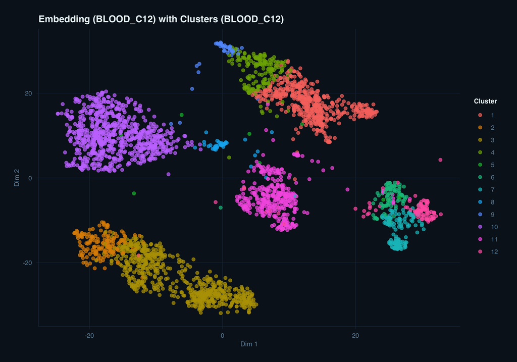

```r
plotEmbeddingWithClusters(blood,
                          embeddingRunID  = "BLOOD_C12",
                          clusteringRunID = "BLOOD_C12")
```

### Lymph Node (UMAP)

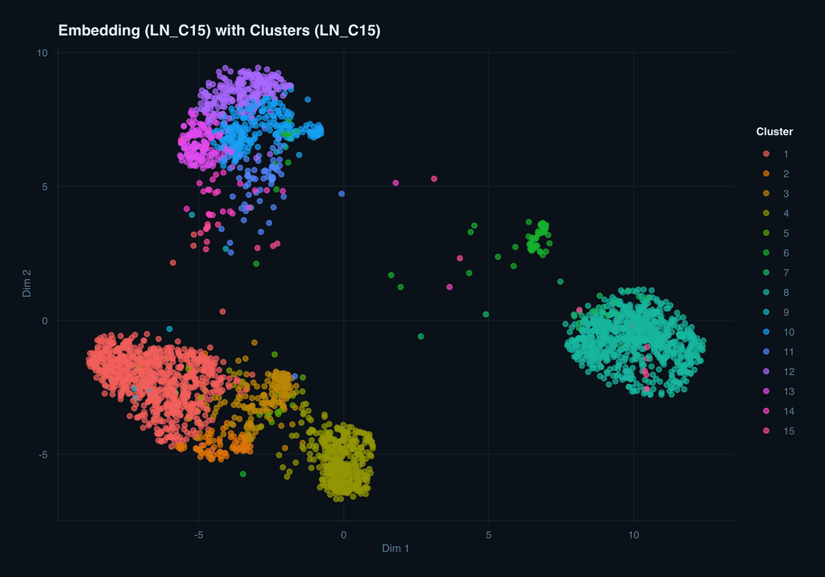

```r
plotEmbeddingWithClusters(lymphNode,
                          embeddingRunID  = "LN_C15",
                          clusteringRunID = "LN_C15")
```

### Liver (UMAP)

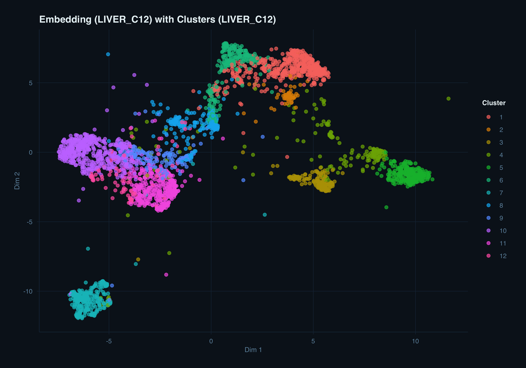

```r
plotEmbeddingWithClusters(liver,
                          embeddingRunID  = "LIVER_C12",
                          clusteringRunID = "LIVER_C12")
```

### Spleen (UMAP)

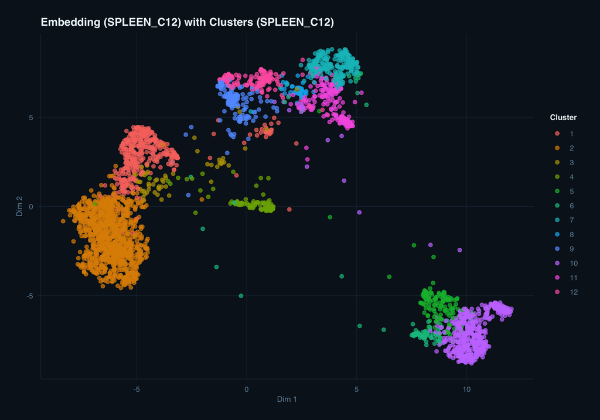

```r
plotEmbeddingWithClusters(spleen,
                          embeddingRunID  = "SPLEEN_C12",
                          clusteringRunID = "SPLEEN_C12")
```

## Cluster Heatmaps

The `plotClusterHeatmap()` function generates marker-by-cluster heatmaps — critical for **phenotypic interpretation** of discovered populations. By examining which markers are high or low in each cluster, you can assign biological identity (e.g., CD3+CD8+ → cytotoxic T cells).

### Full Marker Panel (Row-Scaled)

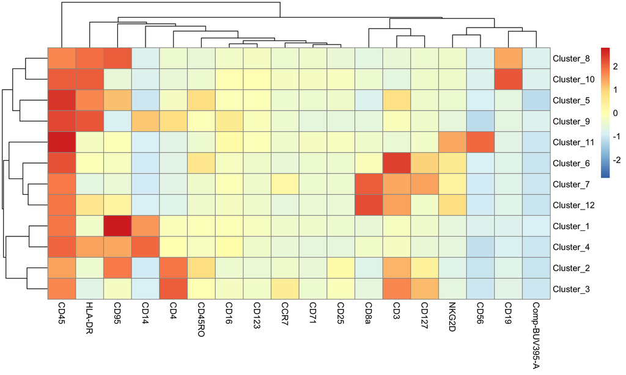

```r
blood <- plotClusterHeatmap(blood, clusteringRunID = "BLOOD_C12")
```

```r
# Verify storage in the S4 plot list
cat("Plots stored:", length(blood@plotList), "\n")
```

```
#> Plots stored: 1
```

```r
cat("Plot type:   ", blood@plotList[[1]]@plotType, "\n")
```

```
#> Plot type:    heatmap
```

```r
cat("Run ID:      ", blood@plotList[[1]]@runID, "\n")
```

```
#> Run ID:       BLOOD_C12
```

### Selected Immune Markers (Unscaled)

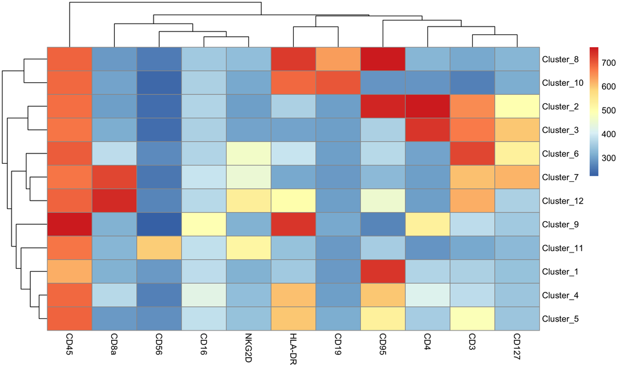

```r
blood <- plotClusterHeatmap(blood,
                            clusteringRunID = "BLOOD_C12",
                            markers = c("CD45", "HLA-DR", "CD16", "CD8a",
                                        "CD4", "CD3", "CD19", "CD56",
                                        "CD127", "CD95", "NKG2D"),
                            scale = "none")
```

```r
cat("Total plots stored:", length(blood@plotList), "\n")
```

```
#> Total plots stored: 2
```

## Cluster vs Rest Marker Comparison

While heatmaps give a bird’s-eye view of all clusters at once, it’s often useful to **drill into a single cluster** and ask: *which markers distinguish this population from everything else?* The `plotClusterMarkerComparison()` function answers this by generating a panel of boxplots or violin plots — one per marker — comparing the selected cluster’s expression against all other cells (“Rest”).

Crucially, the panels are **sorted by the magnitude of difference** (absolute median difference), so the markers that best define the focal cluster appear first.

### Blood — Cluster 1 Boxplots (All Markers)

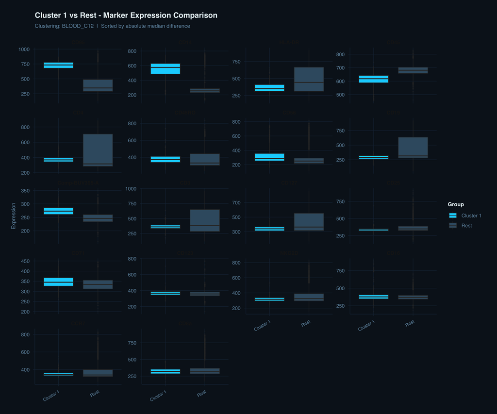

```r
blood <- plotClusterMarkerComparison(blood,
                                     clusteringRunID = "BLOOD_C12",
                                     clusterID       = 1)
```

### Blood — Cluster 5 Violin Plots (Selected Immune Markers)

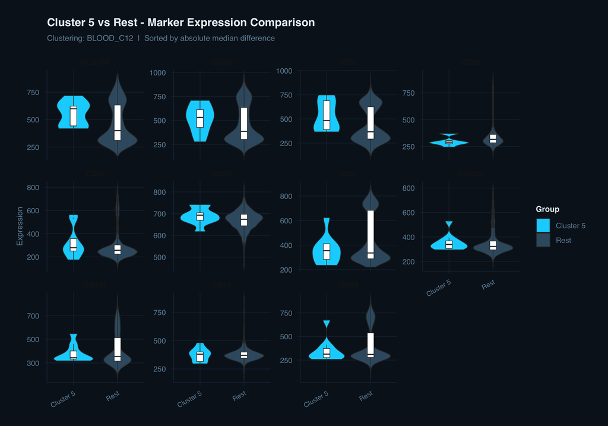

```r
blood <- plotClusterMarkerComparison(blood,
                                     clusteringRunID = "BLOOD_C12",
                                     clusterID       = 5,
                                     plotType        = "violin",
                                     markers         = c("CD45", "HLA-DR", "CD16", "CD8a",
                                                         "CD4", "CD3", "CD19", "CD56",
                                                         "CD127", "CD95", "NKG2D"))
```

**Interpreting the Sort Order** — Markers appearing in the top-left panels show the greatest expression difference between the focal cluster and all other cells. This makes it easy to quickly identify the phenotypic signature of any cluster without scanning through every marker manually.

## Comparing FlowSOM and SOM Clustering

Because every result is stored under its own `runID`, we can overlay the `SOM` clusters on the Blood t-SNE embedding that was computed earlier. The embedding does not change; only the cluster labels do.

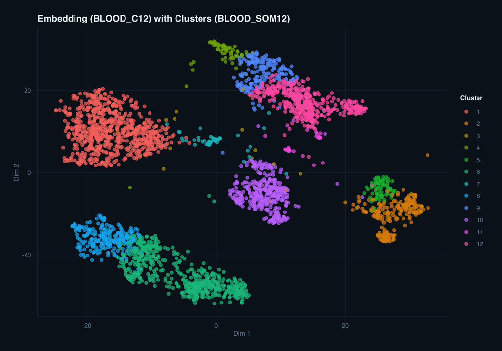

```r
plotEmbeddingWithClusters(blood,
                          embeddingRunID  = "BLOOD_C12",
                          clusteringRunID = "BLOOD_SOM12")
```

The same heatmap used for FlowSOM works unchanged on the `SOM` clusters:

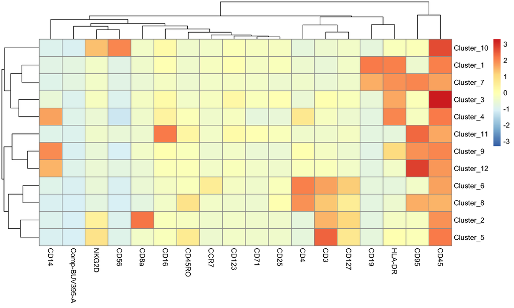

```r
blood <- plotClusterHeatmap(blood, clusteringRunID = "BLOOD_SOM12")
```

### How closely do the two methods agree?

The cross-tabulation shows how the cells of each FlowSOM cluster (rows) are split across the `SOM` clusters (columns). The adjusted Rand index summarises the overall agreement: 1 means identical groupings and values near 0 mean no better than chance.

```r
getClusters <- function(obj, runID) {
  Filter(function(x) x@runID == runID, obj@clusteringList)[[1]]@result$clusters
}
flowsom <- getClusters(blood, "BLOOD_C12")
som     <- getClusters(blood, "BLOOD_SOM12")

table(FlowSOM = flowsom, SOM = som)
```

```
#>        SOM
#> FlowSOM   1   2   3   4   5   6   7   8   9  10  11  12
#>      1    0   0   0   0   0   0   1   1  51   2  23 434
#>      2    0   0   0   0   0   0   0 175   0   0   0   0
#>      3    0   0   0   0   0 541   0  70   0   0   0   0
#>      4    0   0   1  32   0   0   1   0 138   0   0   2
#>      5    0   2   3   1   2   0   0   0   0   1   0   0
#>      6    0  17   0   0  75   1   0   0   0   1   0   0
#>      7    0 138   0   0   0   0   0   0   0   0   0   0
#>      8    1   0   0   0   0   0  35   0   0   1   0   0
#>      9    0   0   3  35   0   0   0   0   0   0   0   0
#>      10 737   0   2   0   0   0   9   0   0   0   0   0
#>      11   0   0   4   0   5   0   1   0   0 338  13   3
#>      12   0  89   2   0   2   1   0   0   0   6   0   0
```

```r
adjustedRand <- function(a, b) {
  tab <- table(a, b)
  choose2 <- function(x) x * (x - 1) / 2
  sumCells <- sum(choose2(tab))
  sumRows  <- sum(choose2(rowSums(tab)))
  sumCols  <- sum(choose2(colSums(tab)))
  expected <- sumRows * sumCols / choose2(sum(tab))
  (sumCells - expected) / ((sumRows + sumCols) / 2 - expected)
}
cat("Adjusted Rand index (FlowSOM vs SOM):", round(adjustedRand(flowsom, som), 3), "\n")
```

```
#> Adjusted Rand index (FlowSOM vs SOM): 0.876
```

## Merged Multi-Tissue Analysis

One of CytoCrunch’s key capabilities is **merging multiple CytoCrunch objects** for cross-tissue comparison. The `mergeCytoCrunchObjects()` function concatenates expression data, embeddings, and cluster assignments while preserving sample provenance.

```r
# Merge Blood and Lymph Node for cross-tissue comparison
mergedCC <- mergeCytoCrunchObjects(
  list(blood, lymphNode),
  c("BLOOD_C12", "LN_C15")
)
```

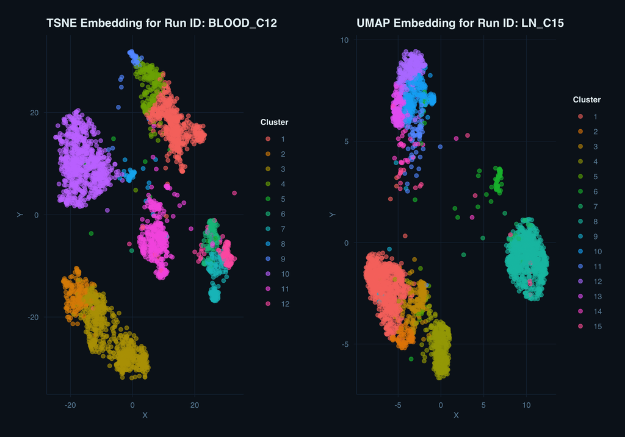

```r
plotMergedEmbeddings(mergedCC)
```

# Reusable UMAP: Apply on Map

The `performEmbedding()` methods shown earlier are based on EmbedSOM and do not keep a model that can be reused. For workflows where **new cells must be placed into an existing map**, such as FlowJo’s “Apply on Map”, CytoCrunch provides a direct `uwot` path:

| Function | Purpose |
| --- | --- |
| `runUwot()` | Run UMAP (unsupervised, or supervised on a label column) and keep the fitted model |
| `saveEmbeddingModel()` / `loadEmbeddingModel()` | Write and read one self-contained model file |
| `applyEmbeddingModel()` | Place new data into a saved map |
| `getEmbedding()` / `getEmbeddingInfo()` | Retrieve coordinates and run details |

## Fit a UMAP and Keep the Model

```r
blood <- runUwot(blood,
                 runID      = "BLOOD_UMAP",
                 nNeighbors = 15,
                 minDist    = 0.1,
                 seed       = 42,
                 nThreads   = 2)

dim(getEmbedding(blood, "BLOOD_UMAP"))
```

```
#> [1] 3000    2
```

```r
getEmbeddingInfo(blood, "BLOOD_UMAP")
```

```
#> $type
#> [1] "UMAP"
#>
#> $nDims
#> [1] 2
#>
#> $modelRunID
#> [1] "BLOOD_UMAP"
#>
#> $threadsUsed
#> [1] 2
```

`getEmbeddingInfo()` reports the embedding type (`"UMAP"`, or `"sUMAP"` for supervised runs), the number of dimensions, the run that holds the model, and the number of threads used. By default all expression columns are used as features; pass `markers = c(...)` to use a subset, and `y = "<column>"` (with `targetWeight`) to supervise the map with a column of cluster labels, where 0 means unlabeled.

## Using Multiple Threads

UMAP is the slowest step for large populations, so `runUwot()` and `applyEmbeddingModel()` can use several threads through the `nThreads` argument. If you do not set it, CytoCrunch uses `max(1, parallel::detectCores() - 1)` threads, leaving one core free.

With **uwot 0.2.0 or newer**, multithreaded runs are also reproducible: CytoCrunch passes `n_threads`, `n_sgd_threads`, `batch = TRUE` and your `seed` to uwot. Running the same data with the same seed and the same `nThreads` therefore gives identical coordinates:

```r
blood <- runUwot(blood,
                 runID      = "BLOOD_UMAP_REPEAT",
                 nNeighbors = 15,
                 minDist    = 0.1,
                 seed       = 42,
                 nThreads   = 2)

cat("uwot version:", as.character(packageVersion("uwot")), "\n")
```

```
#> uwot version: 0.2.4
```

```r
cat("Identical to first run:",
    identical(getEmbedding(blood, "BLOOD_UMAP"),
              getEmbedding(blood, "BLOOD_UMAP_REPEAT")), "\n")
```

```
#> Identical to first run: TRUE
```

**Threads and reproducibility** — Keep `nThreads` fixed (and record it) when you need exactly repeatable maps; the number used is stored with each run and returned by `getEmbeddingInfo()`. On older uwot versions (before 0.2.0) CytoCrunch cannot control threading: it sets the seed and runs without the threading arguments, and `threadsUsed` is reported as `NA`. On shared machines, choose a smaller `nThreads` than the default.

## Save the Model

`saveEmbeddingModel()` writes the model, the marker names in training order, and the run settings into **one file**. Nothing in it points to a path on your machine, so the file keeps working after you move it to another folder or computer.

```r
modelFile <- file.path(tempdir(), "blood_umap_model.rds")
saveEmbeddingModel(blood, "BLOOD_UMAP", modelFile)
file.exists(modelFile)
```

```
#> [1] TRUE
```

In practice, save the file somewhere permanent. It is a normal `.rds` file that you can load later, even in a new R session.

## Apply the Map to New Data

Now we load the model and place the **Lymph Node** cells into the map trained on **Blood**. `applyEmbeddingModel()` matches columns to the model **by name** and reorders them to the training order, so the new data’s column order does not matter, and any extra columns are ignored.

```r
savedModel <- loadEmbeddingModel(modelFile)

lymphNode <- applyEmbeddingModel(lymphNode,
                                 savedModel,
                                 runID    = "LN_ON_BLOOD",
                                 nThreads = 2)

getEmbeddingInfo(lymphNode, "LN_ON_BLOOD")
```

```
#> $type
#> [1] "UMAP"
#>
#> $nDims
#> [1] 2
#>
#> $modelRunID
#> [1] "BLOOD_UMAP"
#>
#> $threadsUsed
#> [1] 2
```

The reported `modelRunID` is the run the map came from. The applied cells are positioned relative to the Blood cells, so both sets share one coordinate system and can be plotted together:

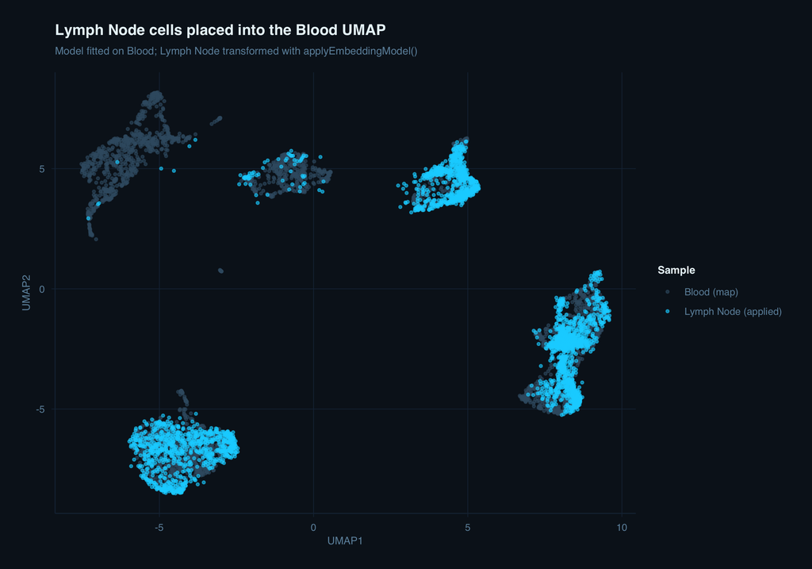

```r
bloodXY <- getEmbedding(blood, "BLOOD_UMAP")
lnXY    <- getEmbedding(lymphNode, "LN_ON_BLOOD")

mapDF <- rbind(
  data.frame(UMAP1 = bloodXY[, 1], UMAP2 = bloodXY[, 2], sample = "Blood (map)"),
  data.frame(UMAP1 = lnXY[, 1],    UMAP2 = lnXY[, 2],    sample = "Lymph Node (applied)")
)

ggplot(mapDF, aes(x = UMAP1, y = UMAP2, color = sample)) +
  geom_point(alpha = 0.6, size = 0.9) +
  scale_color_manual(values = c("Blood (map)" = "#3a5a70",
                                "Lymph Node (applied)" = "#00d4ff")) +
  labs(title    = "Lymph Node cells placed into the Blood UMAP",
       subtitle = "Model fitted on Blood; Lymph Node transformed with applyEmbeddingModel()",
       color    = "Sample")
```

Regions where the Lymph Node cells overlap the Blood cells are phenotypes the two tissues share; Lymph Node cells that land away from the Blood cloud have no close counterpart in the Blood map.

## What Happens If a Marker Is Missing?

Because matching is by name, new data must contain every marker the model was trained on. If any are missing, `applyEmbeddingModel()` stops and lists them rather than silently guessing:

```r
incomplete <- lymphNode
incomplete@inputCSV$X <- incomplete@inputCSV$X[, -(1:2)]

msg <- tryCatch(
  applyEmbeddingModel(incomplete, savedModel, runID = "BROKEN", nThreads = 2),
  error = function(e) conditionMessage(e)
)
cat(msg)
```

```
#> Cannot apply the model: marker(s) missing from the data: Comp-FITC-A :: CCR7, Comp-PerCP-Cy5-5-A :: CD16
```

CytoCrunch · Joshua Luthy · github.com/jluthy/CytoCrunch